# CPSC 330 Lecture 7: Linear models

Andrew Roth (Slides adapted from Varada Kolhatkar and Firas Moosvi)

## Announcements

- Important information about midterm 1
  - https://piazza.com/class/m4ujp0s4xgm5o5/post/204
- HW3 is due next week Monday, Feb 3rd, 11:59 pm.
  - You can work in pairs for this assignment.
- Where to find slides?
  - https://aroth85.github.io/cpsc330-slides/lecture.html

## Learning outcomes

From this lecture, students are expected to be able to:

- Explain the advantages of getting probability scores instead of hard predictions during classification
- Explain the general intuition behind linear models
- Explain the difference between linear regression and logistic regression
- Explain how `predict` works for linear regression
- Explain how can you interpret model predictions using coefficients learned by a linear model
- Explain the advantages and limitations of linear classifiers

## Learning outcomes (contd)

- Broadly describe linear SVMs
- Demonstrate how the `alpha` hyperparameter of `Ridge` is related to the fundamental tradeoff
- Use `scikit-learn`’s `Ridge` model
- Use `scikit-learn`’s `LogisticRegression` model and `predict_proba` to get probability scores

## Recap: Dealing with text features

- Preprocessing text to fit into machine learning models using text vectorization.
- Bag of words representation

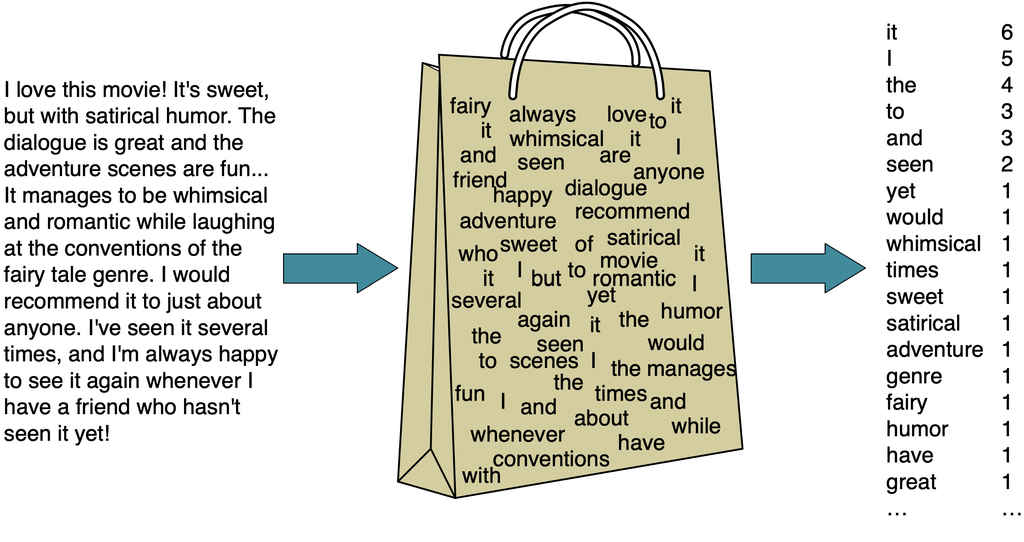

## Recap: `sklearn` `CountVectorizer`

- Use `scikit-learn`’s `CountVectorizer` to encode text data
- `CountVectorizer`: Transforms text into a matrix of token counts
- Important parameters:
  - `max_features`: Control the number of features used in the model
  - `max_df`, `min_df`: Control document frequency thresholds
  - `ngram_range`: Defines the range of n-grams to be extracted
  - `stop_words`: Enables the removal of common words that are typically uninformative in most applications, such as “and”, “the”, etc.

## Recap: Incorporating text features in a machine learning pipeline

```python
from sklearn.feature_extraction.text import CountVectorizer
from sklearn.svm import SVC
from sklearn.pipeline import make_pipeline

text_pipeline = make_pipeline(
    CountVectorizer(),
    SVC()
)
```

## (iClicker) Exercise 6.1

iClicker cloud join link: **https://join.iclicker.com/HTRZ**

**Select all of the following statements which are TRUE.**

- 1. You could carry out cross-validation by passing a `ColumnTransformer` object to `cross_validate`.
- 2. After applying column transformer, the order of the columns in the transformed data has to be the same as the order of the columns in the original data.
- 3. After applying a column transformer, the transformed data is always going to be of different shape than the original data.
- 4. When you call `fit_transform` on a `ColumnTransformer` object, you get a numpy ndarray.

## (iClicker) Exercise 6.2

iClicker cloud join link: **https://join.iclicker.com/HTRZ**

Select all of the following statements which are TRUE.

- 1. `handle_unknown="ignore"` would treat all unknown categories equally.
- 2. As you increase the value for `max_features` hyperparameter of `CountVectorizer` the training score is likely to go up.
- 3. Suppose you are encoding text data using `CountVectorizer`. If you encounter a word in the validation or the test split that’s not available in the training data, we’ll get an error.
- 4. In the code below, inside `cross_validate`, each fold might have slightly different number of features (columns) in the fold.

```python
pipe = (CountVectorizer(), SVC())
cross_validate(pipe, X_train, y_train)
```

# Linear models

## Linear models

- Linear models make an assumption that the relationship between `X` and `y` is linear.
- In this case, with only one feature, our model is a straight line.
- What do we need to represent a line?
  - Slope ($w_1$): Determines the angle of the line.
  - Y-intercept ($w_0$): Where the line crosses the y-axis.

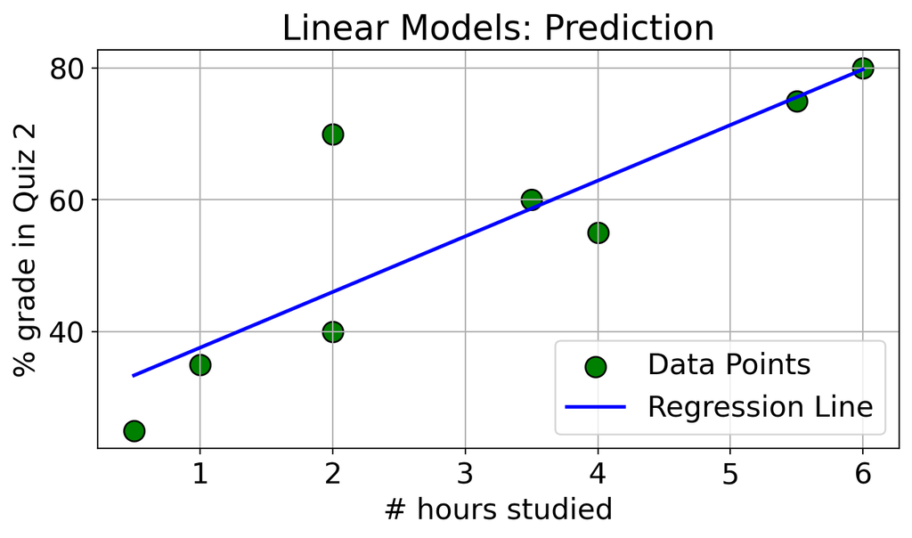

- Making predictions

$$y_{hat} = w_1 \times \text{# hours studied} + w_0$$

## `Ridge` vs. `LinearRegression`

- Ordinary linear regression is sensitive to **multicolinearity** and overfitting
- Multicolinearity: Overlapping and redundant features. Most of the real-world datasets have colinear features.
- Linear regression may produce large and unstable coefficients in such cases.
- [`Ridge`](https://scikit-learn.org/1.5/modules/linear_model.html#ridge-regression) adds a parameter to control the complexity of a model. Finds a line that balances fit and prevents overly large coefficients.

## When to use what?

- `LinearRegression`
  - When interpretability is key, and no multicollinearity exists
- `Ridge`
  - When you have **multicollinearity** (highly correlated features).
  - When you want to prevent **overfitting** in linear models.
- **In this course, we’ll use `Ridge`.**

## (iClicker) Exercise 7.1

iClicker cloud join link: **https://join.iclicker.com/HTRZ**

Select all of the following statements which are TRUE.

- 1. Increasing the hyperparameter `alpha` of `Ridge` is likely to decrease model complexity.
- 2. `Ridge` can be used with datasets that have multiple features.
- 3. With `Ridge`, we learn one coefficient per training example.
- 4. If you train a linear regression model on a 2-dimensional problem (2 features), the model will learn 3 parameters: one for each feature and one for the bias term.

## Logistic regression

- Suppose your target is binary: pass or fail
- Logistic regression is used for such binary classification tasks.
- Logistic regression predicts a probability that the given example belongs to a particular class.
- It uses **Sigmoid function** to map any real-valued input into a value between 0 and 1, representing the probability of a specific outcome.
- A threshold (usually 0.5) is applied to the predicted probability to decide the final class label.

## Logistic regression: Decision boundary

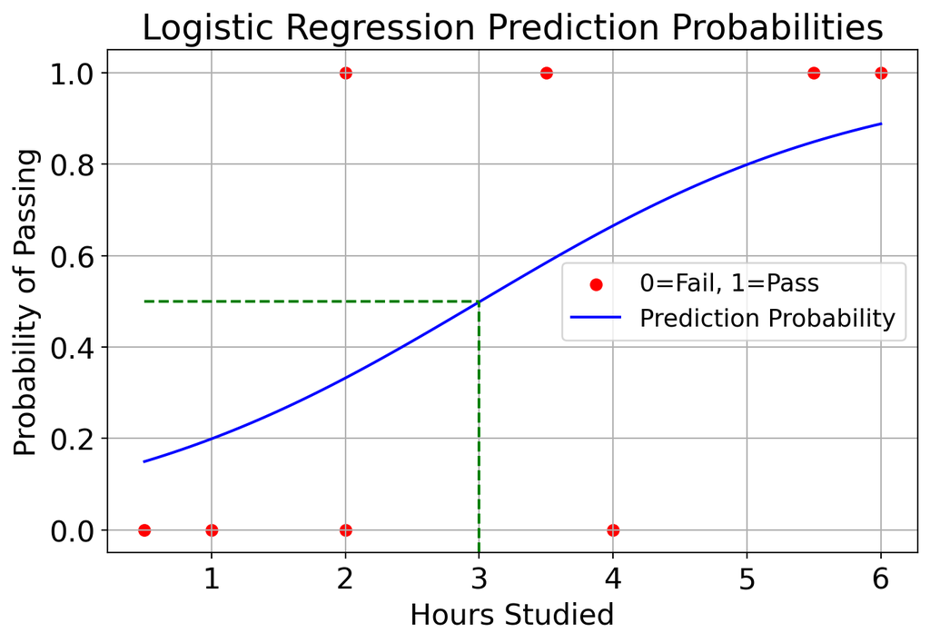

- The decision boundary is the point on the x-axis where the corresponding predicted probability on the y-axis is 0.5.

## Decision boundary of logistic regression

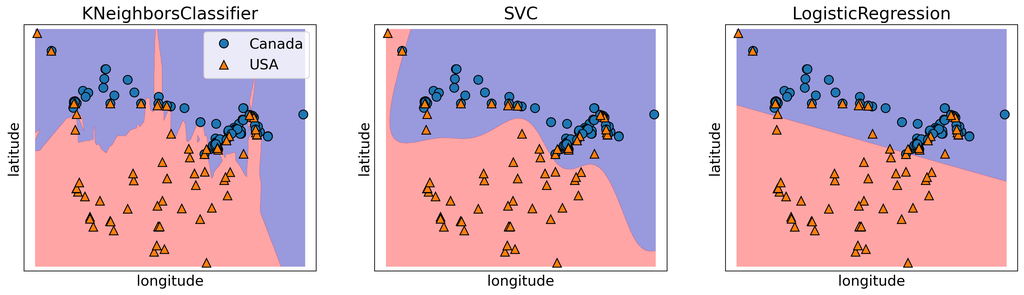

## Parametric vs. non-Parametric models (high-level)

- Imagine you are training a logistic regression model. For each of the following scenarios, identify how many parameters (weights and biases) will be learned.
- Scenario 1: 100 features and 1,000 examples
- Scenario 2: 100 features and 1 million examples

## Parametric vs. non-Parametric models (high-level)

#### Parametric

- Examples: Logistic regression, linear regression, linear SVM
- Models with a fixed number of parameters, regardless of the dataset size
- Simple, computationally efficient, less prone to overfitting
- Less flexible, may not capture complex relationships

#### Non parametric

- Examples: KNN, SVM RBF, Decision tree with no specific depth specified
- Models where the number of parameters grows with the dataset size. They do not assume a fixed form for the functions being learned.
- Flexible, can adapt to complex patterns
- Computationally expensive, risk of overfitting with noisy data

# [Class demo](https://github.com/UBC-CS/cpsc330-2024W2/blob/main/lectures/204-Andy-lectures/class_demos/demo_07-linear-models_clean.ipynb)

## (iClicker) Exercise 7.2

iClicker cloud join link: **https://join.iclicker.com/HTRZ**

Select all of the following statements which are TRUE.

- 1. Increasing logistic regression’s `C` hyperparameter increases model complexity.
- 2. The raw output score can be used to calculate the probability score for a given prediction.
- 3. For linear classifier trained on $d$ features, the decision boundary is a $d-1$-dimensional hyperparlane.
- 4. A linear model is likely to be uncertain about the data points close to the decision boundary.

## Linear SVM

- We have seen non-linear SVM with RBF kernel before. This is the default SVC model in `sklearn` because it tends to work better in many cases.
- There is also a linear SVM. You can pass `kernel="linear"` to create a linear SVM.
- `predict` method of linear SVM and logistic regression works the same way.
- We can get `coef_` associated with the features and `intercept_` using a Linear SVM model

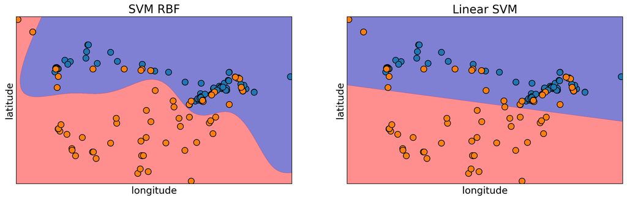

## Summary

## Summary of linear models

- Linear regression is a linear model for regression whereas logistic regression is a linear model for classification.
- Both these models learn one coefficient per feature, plus an intercept.

## Interpretation of coefficients in linear models

- The $j$th coefficient tells us how feature $j$ affects the prediction
  - if $w_j > 0$ then increasing $x_{ij}$ moves us toward predicting $+1$
  - if $w_j < 0$ then increasing $x_{ij}$ moves us toward prediction $-1$
  - if $w_j = 0$ then the feature is not used in making a prediction

## Importance of scaling

- When you are interpreting the model coefficients, scaling is crucial.
- If you do not scale the data, features with smaller magnitude are going to get coefficients with bigger magnitude whereas features with bigger scale are going to get coefficients with smaller magnitude.
- That said, when you scale the data, feature values become hard to interpret for humans!

## Limitations of linear models

[figure not shown]